# Frogs in Nimble

HME Spr 2025

updated on 2025-01-29

# What Is NIMBLE?

- A framework for hierarchical statistical models and methods.
- A nearly drop-in alternative to WinBUGS, OpenBUGS and JAGS.
- An extension of the BUGS language for writing new functions and distributions.
- A configurable system for MCMC.
- A library of other methods.
- A model-generic programming system to write new analysis methods.
- Numerical Inference for statistical Models using Bayesian and Likelihood Estimation.

# First example: Frogs at the pond

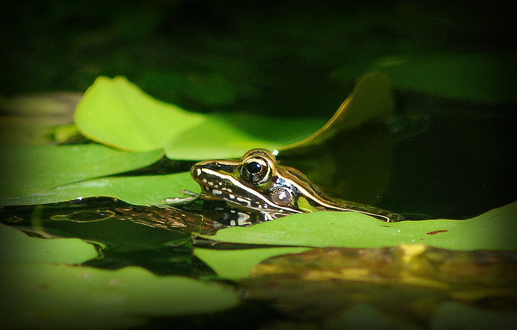

a frog at a pond

# Frogs at the pond: Load the package

```r
library(nimble)
```

# Frogs at the pond: Write the model code **in R**

- WinBUGS and JAGS usually required passing a text file or writing a new text file within R
- Now we just use the function `nimbleCode`
- First model: we don’t know anything about the frog and its ecological needs, so we assume 50/50 prob of occurrence

# Frogs at the pond: Write the model code **in R**

```r
frog_code01 <- nimbleCode({

  ## ## ## ## ## ## ## ##
  #  Prior Probability  #
  ## ## ## ## ## ## ## ##

  # prior probability of presence given what we know about frog
  prior.knowledge <- 0.5

  # probability of detection is relatively high but depends on presence/absence
  # incorporating prior knowledge of species dectection
  detect.prob <- 0.8 * presence

  ## ## ## ## ## ## ## ##
  #     Likelihood      #
  ## ## ## ## ## ## ## ##

  # actual presence drawn from a Bernoulli distribution
  presence ~ dbern(prior.knowledge)

  # actual detection occurs with random variation that follows a Bernoulli distribution
  detected ~ dbern(detect.prob)


}
)
```

# Frogs at the pond: Write the model code in R (Alternate Coding)

```r
frog_code01 <- nimbleCode({

  ## ## ## ## ## ## ## ##
  #  Prior Probability  #
  ## ## ## ## ## ## ## ##

  # prior probability of presence given what we know about frog
  prior.knowledge <- 0.5

  # probability of detection is relatively high but depends on presence/absence
  detect.prob <- 0.8

  ## ## ## ## ## ## ## ##
  #     Likelihood      #
  ## ## ## ## ## ## ## ##

  # actual presence drawn from a Bernoulli distribution
  presence ~ dbern(prior.knowledge)

  # actual detection occurs with random variation that follows a Bernoulli distribution
  detected ~ dbern(detect.prob*presence) #conditional on presence of species


  }
)
```

# Frogs at the pond: bundle data for `NIMBLE`

- `NIMBLE` differs from previous software in that we can pass *constants* and *data* seperately
  - This can be particularly helpful in the way nimble serves as R objects
  - Also needed when using `NIMBLE` for big simulations
  - (I realize both descriptors are a bit vague - hopefully we can see this in action later in the semester)

```r
frog_data <- list(detected = 0)
```

- Constants are usually scalar values that, you guessed it, do not change…
  - e.g., the number of sites in the dataset

# Frogs at the pond: initial values

- Initial values are random numbers that indicate where our MCMC will start for a random variable.
  - Important that these initial values fall within the range of possible values, which is dictated by the probability distributions the random variables take.
- since no prior *distributions*, no starting values are really needed - we just have prior *probabilities* - MCMC will “start” at the prior probabilities given
- however, when we run this model, we will get a warning from nimble stating `This model is not fully initialized. This is not an error.`
- We could make nimble happy by passing a starting guess of what the value of presence is. We have two options: 1 or 0. Either is fine, it really doesn’t matter (really), and I will show you how you do not have to pick!
  - During the demo, I will show you both approaches so you can see how nimble behaves.
  - From the `nimble` documentation:

    > “Having uninitialized nodes in a NIMBLE model can potentially cause some algorithms to fail and can lead to poor performance in others. Here are some general guidelines on how non-initialized variables can affect performance:

    > MCMC will auto-initialize but will do so from the prior distribution. This can cause slow convergence, especially in the case of diffuse priors.”

```r
initsList <- list(presence = rbinom(1,1,0.5))
```

# Frogs at the pond: Steps needed to quickly get samples with some default settings in `NIMBLE`

1. Write the model (as an `R` object); we already did this (`frog_code01`)
2. Specify data and/or constants; we already did this (`frog_data`)
3. Specify initial values; we already did this (`initsList`)
4. Bundle everything up and pass it to `nimbleMCMC`.

```r
frog_samples01 <- nimbleMCMC(code = frog_code01,
                            data = frog_data,
                            inits = initsList,
                            niter = 10000,
                            nchain = 1,
                            summary = T)
```

```
## Defining model
```

```
## Building model
```

```
## Setting data and initial values
```

```
## Running calculate on model
##   [Note] Any error reports that follow may simply reflect missing values in model variables.
```

```
## Checking model sizes and dimensions
```

```
## Checking model calculations
```

```
## Compiling
##   [Note] This may take a minute.
##   [Note] Use 'showCompilerOutput = TRUE' to see C++ compilation details.
```

```
## running chain 1...
```

```
## |-------------|-------------|-------------|-------------|
## |-------------------------------------------------------|
```

```r
# what did we just create?
str(frog_samples01)
```

```
## List of 2
##  $ samples: num [1:10000, 1] 1 0 0 0 0 0 0 0 0 0 ...
##   ..- attr(*, "dimnames")=List of 2
##   .. ..$ : NULL
##   .. ..$ : chr "presence"
##  $ summary: num [1, 1:5] 0.167 0 0.373 0 1
##   ..- attr(*, "dimnames")=List of 2
##   .. ..$ : chr "presence"
##   .. ..$ : chr [1:5] "Mean" "Median" "St.Dev." "95%CI_low" ...
```

```r
# TWO THINGS
# 10,000 numbers in a matrix with a column header of "presence"
# A summary of our posterior for everything in keepers

(frog_samples01$summary)
```

```
##            Mean Median  St.Dev. 95%CI_low 95%CI_upp
## presence 0.1672      0 0.373173         0         1
```

```r
# with just one chain and a quite simple model, our "model diagnostics" are a bit limited, but we'll do a full inspection once we have a bigger model
```

# Frogs at a (good) pond

```r
frog_code02 <- nimbleCode({

  ## ## ## ## ## ## ## ##
  #  Prior Probability  #
  ## ## ## ## ## ## ## ##

  # prior probability of presence given what we know about the pond
  prior.knowledge <- 0.75

  # probability of detection is relatively high but depends on presence/absence
  # incorporating prior knowledge of species dectection
  detect.prob <- 0.8 * presence

  ## ## ## ## ## ## ## ##
  #     Likelihood      #
  ## ## ## ## ## ## ## ##

  # actual presence drawn from a Bernoulli distribution
  presence ~ dbern(prior.knowledge)

  # actual detection occurs with random variation that follows a Bernoulli distribution
  detected ~ dbern(detect.prob)

  }
)

frog_samples02 <- nimbleMCMC(code = frog_code02,
                            data = frog_data,
                            inits = initsList,
                            niter = 10000,
                            nchain = 1,
                            summary = T)
```

```
## Defining model
```

```
## Building model
```

```
## Setting data and initial values
```

```
## Running calculate on model
##   [Note] Any error reports that follow may simply reflect missing values in model variables.
```

```
## Checking model sizes and dimensions
```

```
## Checking model calculations
```

```
## Compiling
##   [Note] This may take a minute.
##   [Note] Use 'showCompilerOutput = TRUE' to see C++ compilation details.
```

```
## running chain 1...
```

```
## |-------------|-------------|-------------|-------------|
## |-------------------------------------------------------|
```

```r
(frog_samples02$summary) # point estimate nearly identical to solution found analytically
```

```
##            Mean Median   St.Dev. 95%CI_low 95%CI_upp
## presence 0.3656      0 0.4816221         0         1
```

# Frogs at a (poorly suited) pond

Say the pond that was visited has site characteristics that our frog would not typically use. The ecologist thinks the probability of the frog using the site is about 0.1.

Update our frog model to incorporate this prior information and get MCMC samples for the probability of presence.